Estéfano Tuyama

# Hotel Precification Model

## Introduction

#### Problem: Arbitrarily choosing a price for a hotel room isn't efficient in terms of maximizing profit. It can work, but having a ML model that is able to price a hotel room based on existing hotel room prices can be beneficial and time-saving.

#### Approach: This project aims to solve that problem by creating several linear regression models that take in different parameters and aims to compare them and choose the best one for our purposes.

#### Database: Consists of 1000 fictional hotel rooms. Each hotel room has 4 parameters:

- Number of stars (1 to 5)
- Distance to turism (in km)
- Capacity, or the number of people this room can house
- Price (in dollars)

#### Tools used: Python, Pandas, Numpy, Seaborn, Plotly, Statsmodels, Sklearn

#### Taking a look at the first few rows of the Database

```python
df = pd.read_csv('hotels.csv')
df.head()
```

|  | Stars | DistanceToTurism | Capacity | Price |
| --- | --- | --- | --- | --- |
| 0 | 5 | 9.301565 | 3 | 506.275452 |
| 1 | 1 | 1.785891 | 1 | 246.363458 |
| 2 | 4 | 15.504293 | 3 | 325.873550 |
| 3 | 4 | 4.173188 | 3 | 521.343284 |
| 4 | 4 | 9.443685 | 1 | 252.587087 |

#### Checking Database information, so we can see if there are null values or whether or not we need to make type conversions. Luckily, this database seems to be complete

```python
df.info()
```

```
RangeIndex: 1000 entries, 0 to 999
Data columns (total 4 columns):
 #   Column            Non-Null Count  Dtype
---  ------            --------------  -----
 0   Stars             1000 non-null   int64
 1   DistanceToTurism  1000 non-null   float64
 2   Capacity          1000 non-null   int64
 3   Price             1000 non-null   float64
```

#### Looking at a description of the database to see if we find anything uncommon. We found that there are hotel room with negative prices, which is weird.

```python
df.describe()
```

|  | Stars | DistanceToTurism | Capacity | Price |
| --- | --- | --- | --- | --- |
| count | 1000.000000 | 1000.000000 | 1000.000000 | 1000.000000 |
| mean | 3.008000 | 7.650878 | 2.519000 | 396.611361 |
| std | 1.407095 | 5.870137 | 1.108543 | 171.742433 |
| min | 1.000000 | 0.013850 | 1.000000 | -220.208705 |
| 25% | 2.000000 | 3.034775 | 2.000000 | 283.590980 |
| 50% | 3.000000 | 6.430035 | 3.000000 | 401.743527 |
| 75% | 4.000000 | 10.863295 | 4.000000 | 516.097856 |
| max | 5.000000 | 31.709748 | 4.000000 | 836.261308 |

```python
df_price_under_50 = df[df['Price'] < 50].copy()
df = df[df['Price'] >= 50].copy()
```

#### Using Seaborn's pairplot to take a look at which variables are correlated with the price of a hotel.

We can see the distance to turism seems to be highly correlated with the price, and there seems to be a correlation also between stars/capacity and the price.

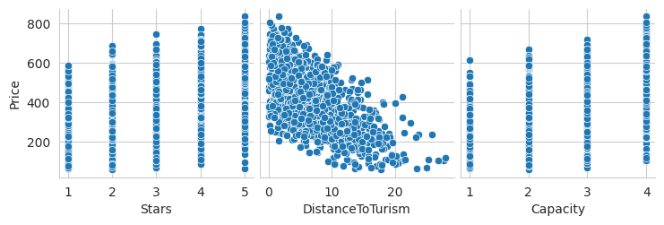

```python
sns.pairplot(df, x_vars=['Stars', 'DistanceToTurism', 'Capacity'], y_vars='Price')
plt.show()
```

#### Separating the data in train/test splits to train our model. We will be using 80% of the data to train and 20% to test

```python
from sklearn.model_selection import train_test_split
x = df.drop(columns='Price')
y = df['Price']
x_train, x_test, y_train, y_test = train_test_split(x, y, test_size=0.2, random_state=136)
```

#### Creating the training DataFrame

```python
df_train = pd.DataFrame(data=x_train)
df_train['Price'] = y_train
df_train.head()
```

|  | Stars | DistanceToTurism | Capacity | Price |
| --- | --- | --- | --- | --- |
| 360 | 5 | 23.466470 | 1 | 61.495168 |
| 700 | 1 | 1.592505 | 2 | 298.057859 |
| 353 | 3 | 2.444435 | 3 | 582.630609 |
| 671 | 3 | 19.223248 | 3 | 220.208619 |
| 262 | 2 | 11.541840 | 4 | 297.254357 |

#### Creating the first model and evaluating it.

A r² score of .43 indicates that the distance to turism does have a correlation with the price, although it doesn't fully explain the price by itself (as expected).

```python
model = ols('Price ~ DistanceToTurism', data=df_train).fit()

model.rsquared
```

```
np.float64(0.43067515674525736)
```

```python
model.resid
```

```
360    -40.298231
700   -214.875867
353     85.709651
671     38.660135
262    -28.672899
          ...
56      84.778015
661    -47.532610
983   -154.795662
240    249.319655
230    -31.831201
Length: 778
```

#### Using the first model to make a prediction using the test data

Since the R² score is not very similar to the training data R² score, we **can't** say this model is consistent. we should then look to create other models.

```python
y_predict = model.predict(x_test)

r2_score(y_test, y_predict)
```

```
0.3192107616205031
```

#### Adding a constant to the training DataFrame

```python
x_train = sm.add_constant(x_train)
x_train.head()
```

|  | const | Stars | DistanceToTurism | Capacity |
| --- | --- | --- | --- | --- |
| 360 | 1.0 | 5 | 23.466470 | 1 |
| 700 | 1.0 | 1 | 1.592505 | 2 |
| 353 | 1.0 | 3 | 2.444435 | 3 |
| 671 | 1.0 | 3 | 19.223248 | 3 |
| 262 | 1.0 | 2 | 11.541840 | 4 |

#### Creating other saturated models, with more variables so we can compare and see which one is better

```python
model_2 = sm.OLS(
    y_train,
    x_train[['const', 'Stars', 'DistanceToTurism', 'Capacity']]
).fit()

model_3 = sm.OLS(
    y_train,
    x_train[['const', 'Stars', 'DistanceToTurism']]
).fit()
model_4 = sm.OLS(
    y_train,
    x_train[['const', 'Stars', 'Capacity']]
).fit()
```

### Comparing all models to select the best one

#### Results: Model 2 achieved R² = 0.91, meaning 91% of price variability is explained by the selected variables. There is also no indication of multicolinearity (we'll check for that more thoroughly later)

```python
model.summary()
```

OLS Regression Results

| Dep. Variable: | Price | R-squared: | 0.431 |
| --- | --- | --- | --- |
| Model: | OLS | Adj. R-squared: | 0.430 |
| Method: | Least Squares | F-statistic: | 587.0 |
| Date: | Thu, 13 Mar 2025 | Prob (F-statistic): | 5.23e-97 |
| Time: | 16:46:43 | Log-Likelihood: | -4815.8 |
| No. Observations: | 778 | AIC: | 9636. |
| Df Residuals: | 776 | BIC: | 9645. |
| Df Model: | 1 |  |  |
| Covariance Type: | nonrobust |  |  |

|  | coef | std err | t | P>\|t\| | [0.025 | 0.975] |
| --- | --- | --- | --- | --- | --- | --- |
| Intercept | 542.8662 | 7.079 | 76.684 | 0.000 | 528.969 | 556.763 |
| DistanceToTurism | -18.7959 | 0.776 | -24.228 | 0.000 | -20.319 | -17.273 |

| Omnibus: | 14.039 | Durbin-Watson: | 2.075 |
| --- | --- | --- | --- |
| Prob(Omnibus): | 0.001 | Jarque-Bera (JB): | 8.130 |
| Skew: | -0.005 | Prob(JB): | 0.0172 |
| Kurtosis: | 2.499 | Cond. No. | 15.4 |

```python
model_2.summary()
```

OLS Regression Results

| Dep. Variable: | Price | R-squared: | 0.913 |
| --- | --- | --- | --- |
| Model: | OLS | Adj. R-squared: | 0.913 |
| Method: | Least Squares | F-statistic: | 2704. |
| Date: | Thu, 13 Mar 2025 | Prob (F-statistic): | 0.00 |
| Time: | 16:46:50 | Log-Likelihood: | -4085.5 |
| No. Observations: | 778 | AIC: | 8179. |
| Df Residuals: | 774 | BIC: | 8198. |
| Df Model: | 3 |  |  |
| Covariance Type: | nonrobust |  |  |

|  | coef | std err | t | P>\|t\| | [0.025 | 0.975] |
| --- | --- | --- | --- | --- | --- | --- |
| const | 196.8588 | 5.985 | 32.894 | 0.000 | 185.111 | 208.607 |
| Stars | 50.3854 | 1.186 | 42.496 | 0.000 | 48.058 | 52.713 |
| DistanceToTurism | -19.5439 | 0.304 | -64.281 | 0.000 | -20.141 | -18.947 |
| Capacity | 78.9019 | 1.512 | 52.195 | 0.000 | 75.934 | 81.869 |

| Omnibus: | 1.482 | Durbin-Watson: | 1.885 |
| --- | --- | --- | --- |
| Prob(Omnibus): | 0.477 | Jarque-Bera (JB): | 1.510 |
| Skew: | -0.062 | Prob(JB): | 0.470 |
| Kurtosis: | 2.823 | Cond. No. | 35.9 |

```python
model_3.summary()
```

OLS Regression Results

| Dep. Variable: | Price | R-squared: | 0.606 |
| --- | --- | --- | --- |
| Model: | OLS | Adj. R-squared: | 0.605 |
| Method: | Least Squares | F-statistic: | 596.9 |
| Date: | Thu, 13 Mar 2025 | Prob (F-statistic): | 1.25e-157 |
| Time: | 16:46:54 | Log-Likelihood: | -4672.3 |
| No. Observations: | 778 | AIC: | 9351. |
| Df Residuals: | 775 | BIC: | 9365. |
| Df Model: | 2 |  |  |
| Covariance Type: | nonrobust |  |  |

|  | coef | std err | t | P>\|t\| | [0.025 | 0.975] |
| --- | --- | --- | --- | --- | --- | --- |
| const | 402.8791 | 9.557 | 42.154 | 0.000 | 384.118 | 421.641 |
| Stars | 46.7724 | 2.515 | 18.599 | 0.000 | 41.836 | 51.709 |
| DistanceToTurism | -18.9726 | 0.646 | -29.390 | 0.000 | -20.240 | -17.705 |

| Omnibus: | 114.275 | Durbin-Watson: | 1.999 |
| --- | --- | --- | --- |
| Prob(Omnibus): | 0.000 | Jarque-Bera (JB): | 27.954 |
| Skew: | -0.009 | Prob(JB): | 8.51e-07 |
| Kurtosis: | 2.072 | Cond. No. | 26.3 |

```python
model_4.summary()
```

OLS Regression Results

| Dep. Variable: | Price | R-squared: | 0.448 |
| --- | --- | --- | --- |
| Model: | OLS | Adj. R-squared: | 0.447 |
| Method: | Least Squares | F-statistic: | 314.5 |
| Date: | Thu, 13 Mar 2025 | Prob (F-statistic): | 1.02e-100 |
| Time: | 16:46:56 | Log-Likelihood: | -4803.8 |
| No. Observations: | 778 | AIC: | 9614. |
| Df Residuals: | 775 | BIC: | 9628. |
| Df Model: | 2 |  |  |
| Covariance Type: | nonrobust |  |  |

|  | coef | std err | t | P>\|t\| | [0.025 | 0.975] |
| --- | --- | --- | --- | --- | --- | --- |
| const | 66.6932 | 14.169 | 4.707 | 0.000 | 38.878 | 94.508 |
| Stars | 49.1060 | 2.983 | 16.463 | 0.000 | 43.251 | 54.961 |
| Capacity | 75.4037 | 3.801 | 19.838 | 0.000 | 67.942 | 82.865 |

| Omnibus: | 42.160 | Durbin-Watson: | 2.004 |
| --- | --- | --- | --- |
| Prob(Omnibus): | 0.000 | Jarque-Bera (JB): | 47.995 |
| Skew: | -0.607 | Prob(JB): | 3.78e-11 |
| Kurtosis: | 3.075 | Cond. No. | 14.8 |

#### Looking at model_2's parameters, we can see how much the price of a hotel is affected by a change in each parameter (everything else remaining constant).

```python
model_2.params
```

```
const               196.858766
Stars                50.385416
DistanceToTurism    -19.543904
Capacity             78.901909
```

#### Adding a constant and predicting the values on the test split using our best model

```python
x_test = sm.add_constant(x_test)

predict_2 = model_2.predict(x_test[['const', 'Stars', 'DistanceToTurism', 'Capacity']])
```

#### Checking that the R² is similar between training and testing.

It is simillar (0.91 vs 0.90), indicating that the model is consistent.

```python
print(r2_score(y_test, predict_2), model_2.rsquared)
```

```
0.8976636624423547 0.9129107017167504
```

#### Next, let's precify a new hotel using our two best models so we can see the difference.

We can see that there is over \$100 of difference between both models' precification of the same hotel room. This is relevant to us as a \$100 difference is very relevant and can make a difference on whether a person will book a hotel room or not

```python
new_hotel = pd.DataFrame({
    'const':[1],
    'Stars':[5],
    'DistanceToTurism':[0.3],
    'Capacity':[4]
})

model_2.predict(new_hotel)[0]
```

```
np.float64(758.5303113576596)
```

```python
new_hotel = new_hotel.drop(columns='Capacity')
model_3.predict(new_hotel)[0]
```

```
np.float64(631.0491442885145)
```

#### The next step is to check for multicolinearity for our model_2.

A vif < 5 is considered to be indicative of no multicolinearity. Our model has very low vif for each variable, which is ideal.

```python
variables = ['const', 'Stars', 'DistanceToTurism', 'Capacity']

vif = pd.DataFrame()

vif['variables'] = variables

vif['vif'] = [variance_inflation_factor(x_train[variables], i) for i in range(len(variables))]

vif
```

|  | variables | vif |
| --- | --- | --- |
| 0 | const | 13.004992 |
| 1 | Stars | 1.003638 |
| 2 | DistanceToTurism | 1.001515 |
| 3 | Capacity | 1.004657 |

#### Making a price prediction x real price graph. Analyzing the graph, we can see a linear trend, which is good; It indicates our model is accurately predicting a price that is feasible for a hotel, even if it isn't perfectly accurate

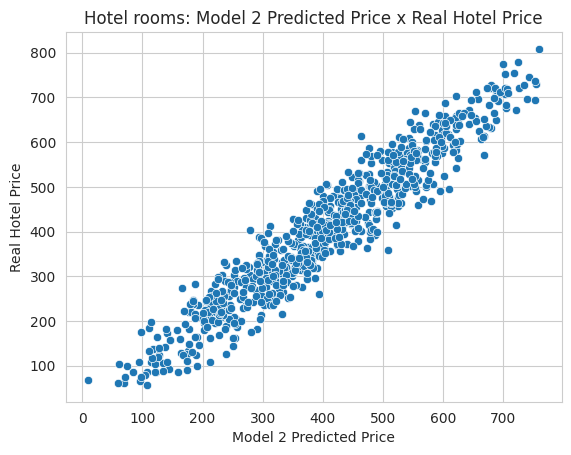

```python
y_predicted_train = model_2.predict(x_train)
sns.set_style('whitegrid')
ax = sns.scatterplot(x=y_predicted_train, y=y_train)
ax.set_title("Hotel rooms: Model 2 Predicted Price x Real Hotel Price")
ax.set_xlabel("Model 2 Predicted Price")
ax.set_ylabel("Real Hotel Price")
plt.show()
```

#### Making a Predicted Price x Residuals graph to analyze heteroscedasticity. The more scattered the graph, the better as that indicates low heteroscedasticity; It indicates that the model is consistent for the price interval we have.

We can see our model has homoscedasticity, as it is scattered all throughout the x axis length

```python
residuals = model_2.resid
```

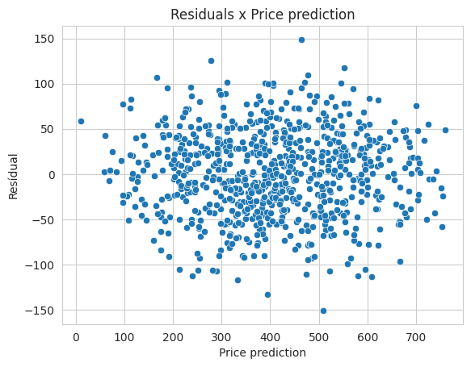

```python
ax = sns.scatterplot(x=y_predicted_train, y=residuals)
ax.set_title('Residuals x Price prediction')
ax.set_xlabel('Price prediction')
ax.set_ylabel('Resídual')
plt.show()
```

### Conclusion/Next steps

We can conclude that model 2 would be the best model for our purposes of predicting a hotel room price.

The next step would be to implement this on a real hotel pricing API. Of course, this database is fictional but similar results can be achieved using a real Database, adjusting it for different variables.

This project was made as an effort to learn about linear regression models and apply them to useful situations. A lot was learned here, as this was my first project of such kind in this area and I am eager to improve, learn more and apply knowledge to real world problems.

Thank you so much for reading!